# Cluster Analysis

Cluster analysis is a technique used in data mining and machine learning to group a set of objects into clusters based on their similarity. Objects in the same cluster are more similar to each other than to those in other clusters. This technique is widely used in exploratory data analysis to uncover hidden patterns or structures within data.

### Applications of Cluster Analysis

- Market Segmentation
  - Group customers based on there attitudes and buying behavior
- Retail
  - Group products based on purchase pattern
  - Fraud detection based on transaction history
- Financial Services
  - Group customers based on financial products or risk profiles
  - Anomaly detection to spot fraud
  - Group stocks based on performance
  - New trends in time series
- Healthcare
  - Group patients based on symptoms
- Image segmentation
  - Organizing images (e.g., for object identification in computer vision)
- Text
  - Group customer reviews
- Input to predictive modeling
  - Cluster then predict

## Data

This dataset is derived from a survey of customers of financial services.

- Respondents were asked to rate the importance of 12 factors in selecting a primary financial provider
- These include performance of investments, fees or commissions charged, depth of products, ability to resolve problems, online services offered, multiple providers’ products to choose from, quality of advice, knowledge of representatives, representative knowing needs, access to other professsional services, degree to which providers knows customer, and quality of service
- Each item was rated on a 1-5 scale where 1 is not at all important and 5 is extremely important.
- Data also includes age, marital status and education of respondents.

Source: Malhotra, Naresh (2010), Marketing Research, 6th ed, Pearson, p. 808-813

```python
import numpy as np
import pandas as pd
import matplotlib.pyplot as plt
import warnings
warnings.filterwarnings('ignore')

raw_data = pd.read_csv("jpm_cluster.csv",na_values=' ')
raw_data.columns = ['id','performance','fees_commissions','depth_of_products','ability_resolve_problems','online_services','choice_of_providers','quality_of_advice','knowledge_of_reps','rep_knowing_your_needs','professional_services','provider_knows_me','quality_of_service',
                'age','marital_status','education']
data = raw_data.copy()
data.head()
```

|  | id | performance | fees_commissions | depth_of_products | ability_resolve_problems | online_services | choice_of_providers | quality_of_advice | knowledge_of_reps | rep_knowing_your_needs | professional_services | provider_knows_me | quality_of_service | age | marital_status | education |
| --- | --- | --- | --- | --- | --- | --- | --- | --- | --- | --- | --- | --- | --- | --- | --- | --- |
| 0 | 1 | 3.0 | 3.0 | NaN | 5.0 | 1.0 | 3.0 | 5.0 | 5.0 | 5.0 | 4.0 | 5.0 | 4.0 | 3.0 | 1.0 | 2.0 |
| 1 | 2 | NaN | NaN | 4.0 | NaN | NaN | NaN | NaN | 4.0 | NaN | NaN | NaN | 4.0 | 2.0 | 1.0 | 1.0 |
| 2 | 3 | 5.0 | 5.0 | 3.0 | 2.0 | 3.0 | 1.0 | 5.0 | 5.0 | 2.0 | 2.0 | 4.0 | 5.0 | 1.0 | 1.0 | 5.0 |
| 3 | 4 | 5.0 | 3.0 | 5.0 | 5.0 | 4.0 | 4.0 | 4.0 | 5.0 | 5.0 | 4.0 | 5.0 | 5.0 | 2.0 | 1.0 | 3.0 |
| 4 | 5 | 5.0 | 5.0 | 4.0 | 4.0 | 4.0 | 5.0 | 5.0 | 5.0 | 5.0 | 4.0 | 5.0 | 4.0 | 4.0 | 1.0 | 2.0 |

## Select Variables

### Needs-Based Variables

Variables in columns 2 - 13 include the needs based-variables. These variables reflect respondent importance rating of twelve features of financial services. We will subset these twelve variables.

```python
data = data.loc[:,'performance':'quality_of_service']
data.head()
```

|  | performance | fees_commissions | depth_of_products | ability_resolve_problems | online_services | choice_of_providers | quality_of_advice | knowledge_of_reps | rep_knowing_your_needs | professional_services | provider_knows_me | quality_of_service |
| --- | --- | --- | --- | --- | --- | --- | --- | --- | --- | --- | --- | --- |
| 0 | 3.0 | 3.0 | NaN | 5.0 | 1.0 | 3.0 | 5.0 | 5.0 | 5.0 | 4.0 | 5.0 | 4.0 |
| 1 | NaN | NaN | 4.0 | NaN | NaN | NaN | NaN | 4.0 | NaN | NaN | NaN | 4.0 |
| 2 | 5.0 | 5.0 | 3.0 | 2.0 | 3.0 | 1.0 | 5.0 | 5.0 | 2.0 | 2.0 | 4.0 | 5.0 |
| 3 | 5.0 | 3.0 | 5.0 | 5.0 | 4.0 | 4.0 | 4.0 | 5.0 | 5.0 | 4.0 | 5.0 | 5.0 |
| 4 | 5.0 | 5.0 | 4.0 | 4.0 | 4.0 | 5.0 | 5.0 | 5.0 | 5.0 | 4.0 | 5.0 | 4.0 |

## Data Preparation

Here are some things to consider before the data can be used for cluster analysis.

- Variable Format: Clustering algorithms prefer all variables to be of the same type. Categorical variables need to be dummy coded.
- Missing Data: Cluster analysis is sensitive to missing data. A missing observation on one variable will cause the entire row to be ignored.
- Scale: Variable scale has an effect on the weight assigned to the variable. Standardizing or normalizing ensures all variables contribute equally.
- Feature selection: Irrelevant or redundant features can muddy cluster patterns. Such variables should be dropped. Similarly, multiple variables representing the same dimension will overweight its importance. Dimension reduction techniques like PCA can reduce feature set while preserving variance.

### Transform format of variables

Clustering algorithms prefer all variables to be of the same type (e.g., int, float, category). Furthermore, clustering algorithms suited for one type may not work well for a different type.

Since all the survey responses in this dataset are numeric variables, there is no need to change the type of the variables.

Note: It is common to treat survey responses gathered on 1-5 scale to be numeric, as we have done here. However, some researchers contend that responses to itemized rating scales are ordinal.

### Impute missing data

Clustering algorithms use data on all variables. A missing observation on one variable will cause the entire row of data to be ignored for analysis. Therefore, it is important to impute missing values.

```python
from sklearn.impute import SimpleImputer
imputer = SimpleImputer(strategy='mean')
data_imputed = imputer.fit_transform(data)
```

### Scale

For distance-based clustering methods, scale of the variable (e.g., seconds vs minutes) affects the weight assigned to the variable. Therefore, it is best to standardize variables.

```python
from sklearn.preprocessing import StandardScaler
scaler = StandardScaler()
data_prepared = scaler.fit_transform(data_imputed)
```

Standardizing involves subtracting the mean and dividing by standard deviation and can be manually computed as shown below.

```python
(data_imputed - np.mean(data_imputed))/np.std(data_imputed)
```

```
array([[-0.76122211, -0.76122211, -0.03371251, ...,  0.17121977,
         1.10366164,  0.17121977],
       [ 0.45013797, -0.0348779 ,  0.17121977, ..., -0.3701317 ,
        -0.14835901,  0.17121977],
       [ 1.10366164,  1.10366164, -0.76122211, ..., -1.69366399,
         0.17121977,  1.10366164],
       ...,
       [ 1.10366164,  0.17121977,  1.10366164, ...,  0.17121977,
         1.10366164,  1.10366164],
       [ 0.17121977, -1.69366399,  0.17121977, ..., -0.76122211,
         0.17121977,  1.10366164],
       [ 1.10366164, -2.62610586,  1.10366164, ...,  1.10366164,
         0.17121977,  1.10366164]], shape=(500, 12))
```

### Redundant Variables

Multiple variables measuring the same dimension should be replaced by the underlying factor or a representative variable. Imagine a survey that uses 3 questions to measure restaurant service and 1 question to measure food quality in the restaurant. Used as such, cluster analysis will on average weight restaurant service three times as much as food quality. When faced with multiple variables measuring an underlying factor, it is best to run a factor analysis and use factors instead of variables. Alternatively, one could combine correlated variables into a single component based on the results of a principal components analysis.

Since we have not examined dimension reduction methods yet, let us assume the survey items used here do not tap any underlying factor and move along.

## Hierarchical Clustering

- Popular method that groups observations according to their similarity
- Distance-based algorithm that operates on a dissimilarity matrix
- Algorithm begins with each observation in its own cluster
- Successively joins neighboring observations or clusters on at a time according to their distances from one another, and continues until all observations are linked
- Process of repeatedly joining observations is called the agglomerative method

Hierarchical clustering builds a tree-like structure (dendrogram) of nested clusters using either an agglomerative (bottom-up) or divisive (top-down) approach.

Strengths:  
- Reveals hierarchical relationships between clusters.  
- Does not require the number of clusters a priori.

Weaknesses:  
- Computationally expensive for large datasets.  
- Sensitive to noise and outliers.

### Distances

Similarity is generally measured using a distance-based measure (as opposed to a correlational measure). Here, we will make use of Euclidean distance to assess similarity. Now, it is important to note that Euclidean distance only works with integer or numeric data.

```python
from scipy.spatial.distance import pdist, squareform
dist_matrix = pdist(data_prepared, metric = 'euclidean')
squareform(np.round(dist_matrix,1))
```

```
array([[0. , 3.3, 6.7, ..., 3.8, 4.2, 5.6],
       [3.3, 0. , 4.9, ..., 3.5, 2.9, 5.2],
       [6.7, 4.9, 0. , ..., 5.6, 5.2, 8.5],
       ...,
       [3.8, 3.5, 5.6, ..., 0. , 4.4, 5. ],
       [4.2, 2.9, 5.2, ..., 4.4, 0. , 4.7],
       [5.6, 5.2, 8.5, ..., 5. , 4.7, 0. ]], shape=(500, 500))
```

### Linkage Method

Distance between pairs of points is useful in identifying similarity between a pair of points. As observations are combined into clusters, distances must now be evaluated among clusters or between a point and a cluster. There are different approaches to grouping observations and these are called clustering methods. These methods differ based on whether they are based on distance (single, complete, average, weighted), variance (ward) or centroid (median, centroid).

```python
from scipy.cluster.hierarchy import linkage, dendrogram, fcluster, cophenet
linked = linkage(pdist(data_prepared), method='ward')  # also works with linkage(data_prepared, method = 'ward')
```

### Dendrogram

The ultimate result of cluster analysis is a dendrogram which looks a bit like an inverted tree. A hierarchical dendrogram is interpreted primarily by height and where observations are joined. The height represents the dissimilarity between elements that are joined.

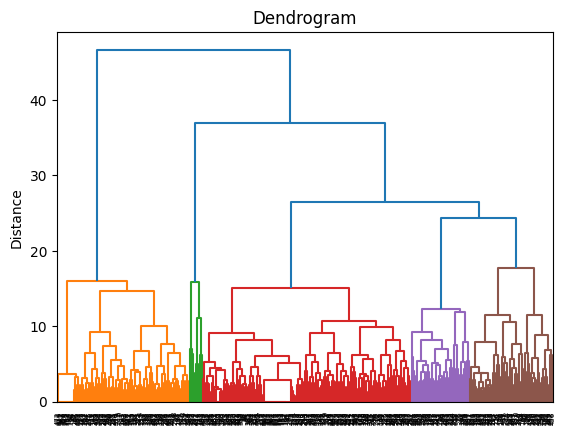

```python
dendrogram(linked,
           distance_sort='ascending',
           color_threshold=20)   # cut tree at 20
plt.title("Dendrogram")
plt.ylabel("Distance")
plt.show()
```

### Goodness of Fit

Before moving on to deciphering the dendrogram, it is useful to look at the Cophenetic correlation coefficient. Cophenetic correlation coefficient (CPC) is a goodness of fit statistic for hierarchical clustering which assesses how well a dendrogram matches the true distance metric. It is interpreted similar to a correlation coefficient. CPC> 0.7 indicates relatively strong fit, 0.3<CPC<0.7 indicates moderate fit.

```python
cophenet(linked, pdist(data_prepared))[0]
```

```
np.float64(0.38016268989189955)
```

### Clusters

Number of clusters may be determined by examining the height between branch splits. A five-cluster solution seems to be best. Most of the respondents seem to be clustering into four groups with one cluster containing a very small number of respondents. For a financial services company, four major segments and one niche segment is a reasonable number of segments to cater to. Based on these considerations, we cut the data into five clusters.

```python
h_clusters = fcluster(linked,
                      t=5,
                      criterion='maxclust')
raw_data['h_clusters'] = h_clusters
raw_data.h_clusters = raw_data.h_clusters.astype('category')
raw_data.h_clusters.value_counts(sort = False)
```

```
h_clusters
1    134
2     13
3    210
4     59
5     84
Name: count, dtype: int64
```

### Cluster Profile

Finally, let us see how these clusters differ.

```python
raw_data.drop(['id','age','marital_status','education'],axis = 1)\
    .groupby(['h_clusters'], observed=True)\
    .aggregate('mean')\
    .round(2)\
    .T
```

| h_clusters | 1 | 2 | 3 | 4 | 5 |
| --- | --- | --- | --- | --- | --- |
| performance | 4.76 | 1.67 | 4.40 | 4.04 | 3.89 |
| fees_commissions | 4.03 | 2.50 | 3.77 | 4.36 | 3.18 |
| depth_of_products | 4.52 | 1.17 | 3.80 | 3.88 | 2.88 |
| ability_resolve_problems | 4.67 | 1.23 | 3.97 | 3.84 | 3.24 |
| online_services | 3.22 | 1.67 | 2.54 | 3.08 | 1.69 |
| choice_of_providers | 4.03 | 1.00 | 3.60 | 3.43 | 2.20 |
| quality_of_advice | 4.92 | 1.67 | 4.33 | 3.40 | 4.01 |
| knowledge_of_reps | 4.92 | 1.31 | 4.35 | 3.51 | 3.68 |
| rep_knowing_your_needs | 4.92 | 2.09 | 4.00 | 2.67 | 3.70 |
| professional_services | 4.30 | 1.17 | 3.46 | 2.71 | 2.76 |
| provider_knows_me | 4.57 | 1.17 | 3.69 | 2.32 | 3.43 |
| quality_of_service | 4.83 | 3.15 | 4.49 | 4.17 | 4.16 |

```python
for var in ['age','marital_status','education']:
    ct = pd.crosstab(raw_data['h_clusters'],raw_data[var], normalize='index')
    ct = (ct*100).round(2)
    print('------------------------------')
    print(ct)
```

```
------------------------------
age           1.0    2.0    3.0    4.0
h_clusters
1           13.74  34.35  32.82  19.08
2            0.00  23.08  30.77  46.15
3           10.50  23.00  34.00  32.50
4           22.22  33.33  33.33  11.11
5            6.02  18.07  38.55  37.35
------------------------------
marital_status    1.0    2.0
h_clusters
1               84.85  15.15
2               92.31   7.69
3               85.22  14.78
4               91.07   8.93
5               87.95  12.05
------------------------------
education     1.0    2.0    3.0    4.0    5.0    6.0
h_clusters
1            8.40  20.61  29.01  10.69  19.85  11.45
2           15.38   0.00  38.46   0.00  23.08  23.08
3            9.80  20.10  26.96  11.27  16.67  15.20
4            3.51  10.53  36.84  12.28  21.05  15.79
5            8.43  18.07  24.10   8.43  22.89  18.07
```

## K-Means Clustering

- Attempts to find groups that are most compact, in terms of the mean sum-of-squares deviation of each observation from the multivariate center (centroid) of its assigned group
- Non-hierarchical process that reaches solution through an iteration
- K-means clustering begins by arbitrarily placing centroids in the data and then iterating from that point to the final solution. - This disorganized approach to clustering produces similar quality of clusters to hierarchical clustering but much faster

#### Strengths

- Fast, simple, and scalable
- Performs well with spherical and uniformly distributed clusters.

#### Weaknesses

- Requires the number of clusters (k) to be specified.
- Sensitive to initialization and outliers.
- Performs poorly when the clusters are not spherical (e.g., elliptical).
- Does not do well with imbalanced clusters.

```python
from sklearn.cluster import KMeans
```

### Fit

k-means clustering begins with random placement of centroids. These starting values can affect the quality of the results. The default method in sklearn, “k-means++” selects initial cluster centroids using sampling based on an empirical probability distribution of the points’ contribution to the overall inertia or within sum of squared errors.

```python
km = KMeans(n_clusters = 5,
            random_state=617,
            init = 'k-means++')  # default
km_clusters = km.fit_predict(data_prepared)
km.inertia_
```

```
3509.185732922923
```

### Number of Clusters

Number of clusters (or centroids) need to be specified for k-means. In the absence of theory on number of clusters, there are two statistical approaches to picking number of clusters.

- Elbow method: Examine a plot of the number of clusters and within sum of squares (also referred to as inertia). The elbow of the plot identifies the optimal number of clusters
- Silhouette method: Silhouette Score measures how similar a point is to its cluster compared to other clusters. A score near 1 indicates well-separated clusters, while a score near 0 means overlapping clusters. It involves computing the silhouette width(s(i)) for each point  
  s(i) = (b(i) - a(i))/max{a(i),b(i)}  
  where
  - a(i) is average distance of a point to all observations within its cluster
  - b(i) is the average distance of a point to all observations in the nearest cluster

-1 <= s(i) <= 1

- s(i) = 1 implies i is in the right cluster
- s(i) = 0 implies i is between two clusters
- s(i) = -1 implies i should be in the nearest cluster

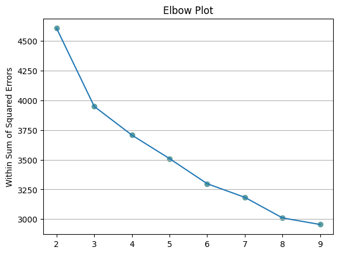

```python
from sklearn.metrics import silhouette_score
within_sse = []
sil = []
k_values = range(2,10)
for k in k_values:
    kmeans = KMeans(n_clusters=k, random_state=617)
    kmeans.fit(data_prepared)
    within_sse.append(kmeans.inertia_)
    sil.append(silhouette_score(X = data_prepared, labels = kmeans.fit_predict(data_prepared)))

plt.scatter(k_values, within_sse, c = 'cadetblue')
plt.plot(k_values, within_sse)
plt.title('Elbow Plot')
plt.ylabel('Within Sum of Squared Errors')
plt.grid(axis = 'y')
plt.show()
```

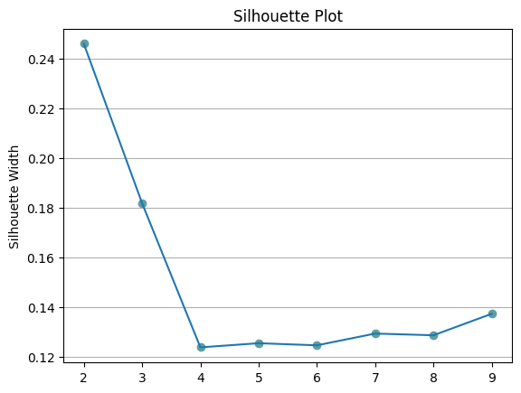

```python
plt.scatter(k_values, sil,c = 'cadetblue')
plt.plot(k_values, sil)
plt.title('Silhouette Plot')
plt.ylabel('Silhouette Width')
plt.grid(axis = 'y')
plt.show()

#import seaborn as sns
#sns.pointplot(x = k_values, y = sil)
```

```python
km = KMeans(n_clusters = 2, random_state=617)
km_clusters = km.fit_predict(data_prepared)
raw_data = raw_data.assign(km_clusters = km_clusters)
raw_data.km_clusters = raw_data.km_clusters.astype('category')
raw_data.km_clusters.value_counts()
raw_data
```

|  | id | performance | fees_commissions | depth_of_products | ability_resolve_problems | online_services | choice_of_providers | quality_of_advice | knowledge_of_reps | rep_knowing_your_needs | professional_services | provider_knows_me | quality_of_service | age | marital_status | education | h_clusters | km_clusters |
| --- | --- | --- | --- | --- | --- | --- | --- | --- | --- | --- | --- | --- | --- | --- | --- | --- | --- | --- |
| 0 | 1 | 3.0 | 3.0 | NaN | 5.0 | 1.0 | 3.0 | 5.0 | 5.0 | 5.0 | 4.0 | 5.0 | 4.0 | 3.0 | 1.0 | 2.0 | 5 | 0 |
| 1 | 2 | NaN | NaN | 4.0 | NaN | NaN | NaN | NaN | 4.0 | NaN | NaN | NaN | 4.0 | 2.0 | 1.0 | 1.0 | 3 | 0 |
| 2 | 3 | 5.0 | 5.0 | 3.0 | 2.0 | 3.0 | 1.0 | 5.0 | 5.0 | 2.0 | 2.0 | 4.0 | 5.0 | 1.0 | 1.0 | 5.0 | 5 | 1 |
| 3 | 4 | 5.0 | 3.0 | 5.0 | 5.0 | 4.0 | 4.0 | 4.0 | 5.0 | 5.0 | 4.0 | 5.0 | 5.0 | 2.0 | 1.0 | 3.0 | 1 | 0 |
| 4 | 5 | 5.0 | 5.0 | 4.0 | 4.0 | 4.0 | 5.0 | 5.0 | 5.0 | 5.0 | 4.0 | 5.0 | 4.0 | 4.0 | 1.0 | 2.0 | 1 | 0 |
| ... | ... | ... | ... | ... | ... | ... | ... | ... | ... | ... | ... | ... | ... | ... | ... | ... | ... | ... |
| 495 | 496 | 4.0 | 4.0 | 4.0 | 4.0 | 3.0 | 3.0 | 4.0 | 4.0 | 4.0 | 4.0 | 4.0 | 5.0 | 4.0 | 2.0 | 3.0 | 3 | 0 |
| 496 | 497 | 3.0 | 3.0 | 3.0 | 3.0 | 1.0 | 2.0 | 4.0 | 3.0 | 4.0 | 2.0 | 3.0 | 4.0 | 4.0 | 1.0 | 5.0 | 5 | 1 |
| 497 | 498 | 5.0 | 4.0 | 5.0 | 5.0 | 3.0 | 2.0 | 5.0 | 5.0 | 5.0 | 4.0 | 5.0 | 5.0 | 2.0 | 1.0 | 5.0 | 1 | 0 |
| 498 | 499 | 4.0 | 2.0 | 4.0 | 3.0 | 3.0 | 3.0 | 4.0 | 4.0 | 4.0 | 3.0 | 4.0 | 5.0 | 4.0 | 1.0 | 3.0 | 3 | 0 |
| 499 | 500 | 5.0 | 1.0 | 5.0 | 5.0 | 5.0 | 5.0 | 5.0 | 5.0 | 5.0 | 5.0 | 4.0 | 5.0 | 3.0 | 1.0 | 5.0 | 1 | 0 |

500 rows × 18 columns

### Cluster Profile

Finally, let us see how these clusters differ.

```python
raw_data.drop(['id','age','marital_status','education','h_clusters'],axis = 1)\
    .groupby(['km_clusters'])\
    .aggregate('mean')\
    .round(2)\
    .T
```

| km_clusters | 0 | 1 |
| --- | --- | --- |
| performance | 4.58 | 3.76 |
| fees_commissions | 3.88 | 3.60 |
| depth_of_products | 4.14 | 3.11 |
| ability_resolve_problems | 4.28 | 3.32 |
| online_services | 2.78 | 2.36 |
| choice_of_providers | 3.73 | 2.73 |
| quality_of_advice | 4.66 | 3.51 |
| knowledge_of_reps | 4.65 | 3.40 |
| rep_knowing_your_needs | 4.50 | 3.07 |
| professional_services | 3.85 | 2.65 |
| provider_knows_me | 4.17 | 2.72 |
| quality_of_service | 4.67 | 4.04 |

```python
for var in ['age','marital_status','education']:
    ct = pd.crosstab(raw_data['km_clusters'],raw_data[var], normalize='index')
    ct = (ct*100).round(2)
    print('--------------------------')
    print(ct)
```

```
--------------------------
age            1.0    2.0    3.0    4.0
km_clusters
0            11.15  26.63  34.98  27.24
1            12.66  25.95  32.91  28.48
--------------------------
marital_status    1.0    2.0
km_clusters
0               84.40  15.60
1               90.62   9.38
--------------------------
education      1.0    2.0    3.0    4.0    5.0    6.0
km_clusters
0            10.09  19.27  27.52  11.01  18.04  14.07
1             5.59  16.15  30.43   9.32  21.74  16.77
```

## Gaussian Mixture Models (GMM)

Key idea of mixture models is that observations come from groups with different statistical distributions (such as different means and variances). The algorithms try to find the best set of such underlying distributions to explain the observed data. These methods are known as mixture models because it is assumed that the data reflect a mixture of observations drawn from different populations.

Since GMM contain a probabilistic model under the hood, it is possible to find probabilistic cluster assignments. The uncertainty of cluster assignment can be visually represented by the size or intensity of dots in a scatterplot.

Like k-means, GMM uses an expectation maximization approach to iterate to the optimal solution. This means, like k-means, the starting values are important.

### Strengths:

- Performs soft clustering (points can belong to multiple clusters).
- Models overlapping clusters effectively.

### Weaknesses:

- Sensitive to initialization.
- Computationally expensive for high-dimensional data.

### Fit

Specifying a 4-cluster model.

```python
from sklearn.mixture import GaussianMixture
gmm = GaussianMixture(n_components=4, random_state=617)
gmm.fit(data_prepared)
gmm_clusters = gmm.predict(data_prepared)
gmm_clusters[:20]
```

```
array([1, 1, 0, 0, 1, 0, 2, 1, 2, 0, 0, 3, 3, 3, 1, 0, 1, 1, 0, 2])
```

### Number of Clusters

Like k-means, the gaussian mixture models do not determine the number of clusters in the data. To determine the number of clusters, AIC and BIC are measured. The optimal cluster solution is the one with minimum AIC and BIC.

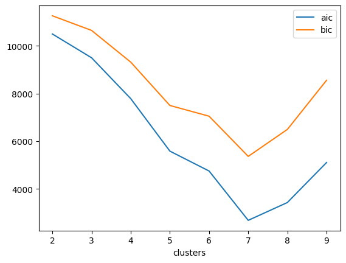

```python
bic_values = []
aic_values = []
for clusters in range(2,10):
    gmm = GaussianMixture(n_components=clusters, random_state=617)
    gmm.fit(data_prepared)
    bic_values.append(gmm.bic(data_prepared))
    aic_values.append(gmm.aic(data_prepared))

pd.DataFrame({'clusters':range(2,10),
              'aic':aic_values,
              'bic': bic_values}).plot(kind='line',x = 'clusters', y = ['aic','bic'])
plt.show()
```

- Based on AIC and BIC, the optimal number of clusters is 7. In practice, business considerations such as the cost of serving seven customer segments may also be considered.
- GMM generates a soft clustering solution allowing a single observation to belong to multiple clusters. For this dataset, the pattern of predicted probabilities indicate unambiguous cluster memberships.

```python
from sklearn.mixture import GaussianMixture
gmm = GaussianMixture(n_components=7, random_state=617)
gmm.fit(data_prepared)
pd.DataFrame(np.round(gmm.predict_proba(data_prepared),3))
```

|  | 0 | 1 | 2 | 3 | 4 | 5 | 6 |
| --- | --- | --- | --- | --- | --- | --- | --- |
| 0 | 1.0 | 0.0 | 0.0 | 0.0 | 0.00 | 0.0 | 0.00 |
| 1 | 0.0 | 1.0 | 0.0 | 0.0 | 0.00 | 0.0 | 0.00 |
| 2 | 0.0 | 0.0 | 0.0 | 0.0 | 0.00 | 1.0 | 0.00 |
| 3 | 0.0 | 0.0 | 0.0 | 0.0 | 0.00 | 1.0 | 0.00 |
| 4 | 1.0 | 0.0 | 0.0 | 0.0 | 0.00 | 0.0 | 0.00 |
| ... | ... | ... | ... | ... | ... | ... | ... |
| 495 | 0.0 | 0.0 | 0.0 | 0.0 | 0.00 | 1.0 | 0.00 |
| 496 | 0.0 | 0.0 | 0.0 | 0.0 | 0.99 | 0.0 | 0.01 |
| 497 | 0.0 | 0.0 | 1.0 | 0.0 | 0.00 | 0.0 | 0.00 |
| 498 | 0.0 | 0.0 | 0.0 | 0.0 | 0.00 | 1.0 | 0.00 |
| 499 | 0.0 | 0.0 | 1.0 | 0.0 | 0.00 | 0.0 | 0.00 |

500 rows × 7 columns

```python
gmm_clusters = gmm.predict(data_prepared)
raw_data = raw_data.assign(gmm_clusters = gmm_clusters)
raw_data.gmm_clusters = raw_data.gmm_clusters.astype('category')
raw_data.gmm_clusters.value_counts(sort=False)
```

```
gmm_clusters
0     39
1    113
2    114
3      8
4     40
5    126
6     60
Name: count, dtype: int64
```